# Project 3: Public Health & Epidemiology

Merrimack College DSE6630: Healthcare & Life Sciences Analytics

Ryan Canfield, Malek Sabri, Tiffany Acosta

24 June 2024

# 1 Introduction

It is **September of 2020**, right in the middle of the COVID-19 pandemic and during the California statewide shutdown. You have just been hired by the California state public health agency to track mortality trends for the past 4 years for which all data have currently been aggregated and de-identified (anonymized). You were given properly de-identified data from 2017 - 2020, which contain mortality records for the state of California by gender, leading cause of death, race / ethnicity, and location of death. All data have been taken from the death certificates filed with the state.

You are provided 6 tables total, which have the following variables.

Table 1. Data dictionary of variables in the California mortality tables.

| **All Tables** |  |
| --- | --- |
| Year | Year of record |
| Month | Month of record |
| County | California county where death was recorded |
| **Annual Mortality Table** |  |
| annualCount | Number of deaths for the sex specified |
| raceEthnicity | Race and/or Ethnicity of the deceased; Latinx is unfortunately treated as a racial category here rather than an ethnic group |
| **Specialized Variables** |  |
| leadingCauseDeath | Leading cause of death per death certificate; See separate table for encoding |
| ageBins | Age groups where the age at death was known |
| ageDeaths | Number of deaths for the age bin specified |
| biologicalSex | Biological sex of decedent |
| sexDeaths | Number of deaths for the sex specified |
| placeDeathOccurred | Location of death, per death certificate |
| placeDeaths | Number of deaths matching specified criteria |
| raceDeaths | Number of deaths matching race / ethnic criteria |
| totalDeaths | Number of deaths per month, year, & county |

Table 2. Underlying cause of death category based on coding using the Tenth Revision of the International Classification of Diseases (ICD) codes

| 3-letter Code | Description | ICD-10 Codes |
| --- | --- | --- |
| HTD | Diseases of the Heart | I00-I09, I11, I13, I20-I51 |
| CAN | Malignant Neoplasms (Cancers) | C00-C97 |
| STK | Cerebrovascular Disease (Stroke) | I60-I69 |
| CLD | Chronic Lower Respiratory Disease (CLRD) | J40-J47 |
| INJ | Unintentional Injuries | V01-X59, Y85-Y86 |
| PNF | Pneumonia and Influenza | J09-J18 |
| DIA | Diabetes Mellitus | E10-E14 |
| ALZ | Alzheimer’s Disease | G30 |
| LIV | Chronic Liver Disease and Cirrhosis | K70, K73-K74 |
| SUI | Intentional Self Harm (Suicide) | U03, X60-X84, Y87.0 |
| HYP | Essential Hypertension and Hypertensive Renal Disease | I10, I12, I15 |
| HOM | Homicide | U01-U02, X85-Y09, Y87.1 |
| NEP | Nephritis, Nephrotic Syndrome and Nephrosis | N00-N07, N17-N19, N25-N27] |
| OTH | All Other Causes of Death | All codes not listed above |

# 2 Using Spatial Analysis to Assess Spatiotemporal Trends in Overall Mortality

## 2.1 Background

Unlike our last project, your data engineering team (i.e., **me**) has provided you with tables that are relatively nice and tidy to begin with - so you can dig right into the analysis. Because these are **spatial data** organized by California county, you first decide you will make maps to analyze both spatial (geographic) and temporal (time) trends. This may give you some insight into the downstream analysis you would like to do. Consider this to be part of your **Exploratory Data Analysis**.

As we discussed in lecture the last 2 weeks, one of the key types of spatial data files we might use are called **shapefiles**, which is what we are going to practice loading and working with shapefiles, using this open source dataset for the state of California. You will have to download these data as they are too large to put onto GiThub. Begin by downloading the requisite spatial data files. Make sure you put them in its own directory called **California_County_Boundaries** on your Desktop; otherwise, you will need to adjust your path in the file settings below. Notice that the directory contains six files, three of them with file extensions we discussed last week in lecture:

- `cnty19_1.cpg`
- `cnty19_1.dbf`
- `cnty19_1.prj`
- `cnty19_1.shp`
- `cnty19_1.shp.xml`
- `cnty19_1.shx`

#### Question 1 [1 point]:

What do each of these six files represent? You will not be able to open them directly on your computer, so you may need to refer back to lecture and do a little digging to figure out the type of data you would expect each of these files to contain. # RRC > `cnty19_1.cpg` – This file specifies the encoding for the shapefile (e.g., UTF-8) to ensure proper character representation.

> `cnty19_1.dbf` – This file stores attribute data related to each county boundaries in CA. Examples of this would be population, area, and administrative info.

> `cnty19_1.prj`: – This file contains the coordinate system and projection information used to geographically position the county boundary data.

> `cnty19_1.shp` – This is the main file that stores all the geometry and shapes of each of the county boundaries in CA. Examples of this would be points, lines, and polygons.

> `cnty19_1.shp.xml` – This file is an XML file that stores metadata about the shapefile. Examples of information that would be found in this file include data sources, creation date, and other descriptive details.

> `cnty19_1.shx` – This file is used to index the geometry in the `cnty19_1.shp` file. This helps to mak things more efficient for accessing the shapefile’s features.

## 2.2 Our objective

We want to first get a sense for **annual trends** in overall mortality across the state to see what we are working with. Our first objective is to join our overall mortality data to the shapefile to be able to make maps to visualize these trends.

## 2.3 Making our first map of California

We are going to practice two ways to make maps from shapefiles so that you can see two ways to do it. Also, to give you more for reference, we are roughly following the GIS Basics Chapter of the Epi R Handbook (with our own twist, of course!). This chapter may be helpful for understanding more of the “nuts and bolts” of GIS as well, including definitions and why we might do things certain ways.

**The initial processing steps will include:** * Import the shapefile * Filter rows to keep only areas of interest * Merging with the other data tables to creates maps and analyze trends

### 2.3.1 Read in the shapefile

We will leverage the `read_sf()` function that is part of the `sf` package. As you might have guessed, `sf` refers to **shapefile**. Note that there is an alternative method to read in shapefiles called `st_read`, which is an alias for `read_sd()` with some different default arguments. By default, `read_sf()` is quiet, whereas `read_st()` will print information about the data source by default. Additionally, `read_sf()` returns a tibble rather than a dataframe. So which to choose? It’s your preference, in this case. We’re going to use read_sf() but we could use `read_st()` if we wanted.

```r
cali_sf <- read_sf("C:/Users/RRC/Downloads/California_County_Boundaries/cnty19_1.shp")
## Alternatively, we can read in the shapefile using the 'st_read()' function
# cali_st <- st_read("./California_County_Boundaries/cnty19_1.shp")
```

Next, let’s take a look at the geometry of the shapefile that we loaded.

```r
cali_sf$geometry
```

```
## Geometry set for 69 features
## Geometry type: MULTIPOLYGON
## Dimension:     XY
## Bounding box:  xmin: -13849230 ymin: 3833650 xmax: -12704980 ymax: 5162403
## Projected CRS: WGS 84 / Pseudo-Mercator
## First 5 geometries:
```

```
## MULTIPOLYGON (((-13611173 4566018, -13611102 45...
```

```
## MULTIPOLYGON (((-13312327 4680816, -13314595 46...
```

```
## MULTIPOLYGON (((-13366406 4679184, -13366429 46...
```

```
## MULTIPOLYGON (((-13478187 4807593, -13478186 48...
```

```
## MULTIPOLYGON (((-13360333 4641183, -13361541 46...
```

Notice that we have a **polygon** geometry in our shapefile. If you were to investigate further, you would find that currently there are no other geometries (e.g., lines or points) in this shapefile. We could add them and export the shapefile, if we ever needed to do so, like to share with someone else.

#### Question 2 [1 point]:

What is the bounding box that comes with our shapefile and what does it tell us? # RRC > The bounding box that is provided with this shapefile specifies the geographic boundaries of the dataset. It gives minimum and maximum coordinates in both the horizontal (x) and vertical (y) dimensions. For this box. xmin and ymin represent the southwestern corner, while xmax and ymax represent the northeastern corner. This is helpful for being precise when mapping the boundary, which lets us prperaly look at and analyze the map, and the shapefile’s features.

#### Question 3 [1 point]:

What is the projection? What does it tell us and why does projection matter? # RRC > I think a projection is used to simulate how the Earth’s surface is curved. When people begain making maps they thought that the Earth was flat, but now that proved that it is curved a projection is needed to compensate for that. In online mapping, it is very common to use “WGS 84 / Pseudo-Mercator” for the projection. “WGS 84 / Pseudo-Mercator” specifies how coordinates are mapped from on a spherical surface to a two-dimensional plane. This also helps with acurracy when analyzing.

### 2.3.2 The most basic map of California using **tmap**.

As you are already aware in R, there are often many ways to accomplish the same goal. The same is true for mapping. In the Mini-Demo for this module, we explored some of the “quick” mapping one can do for EDA using `ggplot2` and the `maps` packages. We are going to show you how to use the `tmap` package now. `tmap` still uses the `ggplot2` underpinnings, but it has some more bells & whistles for maps than just using `ggplot2`.

With `tmap`, you always get started with `tm_shape()`. This is equivalent to the `ggplot()` function you use to start a `ggplot2` map or graph. Note that we are using the `cali_sf` tibble that we imported from a shapefile.

Note that if you’d like to see the Vignette for the `tmap` package, you can find it [here](https://cran.r-project.org/web/packages/tmap/tmap.pdf).

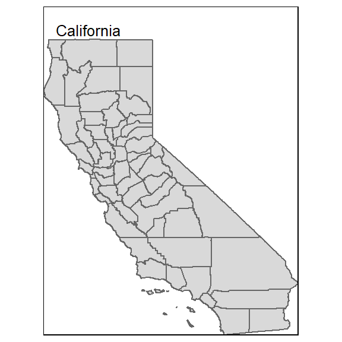

```r
## Start our map in tmap using tm_shape(); we are using the cali_sf tibble we imported
tm_shape(cali_sf) +
  ## Give it a default color fill
  tm_fill() +
  ## Give it default borders
  tm_borders() +
  ## Let's give it a title and specify its placement
  tm_layout(
      "California",
      inner.margins = c(0, 0, 0.1, 0),
      title.size = 0.8)
```

### 2.3.3 The most basic map of California using **ggplot2**.

But what if we did just want to use `ggplot2` again? Will that read a shapefile? Yes! So, let’s try it. Notice that we are using the `geom_sf()` function instead of the `geom_polygon()` function we used in the Mini-Demo.

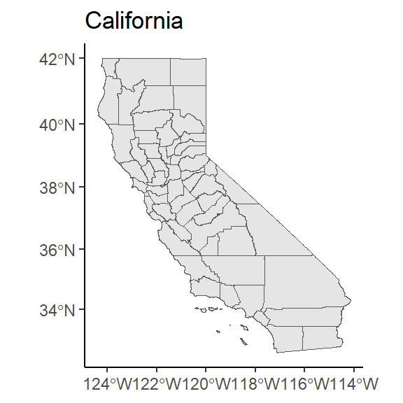

```r
## Initiate the plot and tell it the dataset
ggplot(cali_sf) +
  ## Use the geom_sf function to tell it how to make the map
  geom_sf() +
  ## Set the theme to classic
  theme_classic() +
  ## Let's give it a title
  ggtitle("California")
```

### 2.3.4 Zooming in on the map

Now, what if we only wanted to visualize a few counties? Let’s look at the three northernmost counties that border Oregon using the `tmap` method. Notice that the county names are accessible through `cali_sf$COUNTY_NAM`. We can just use the `filter()` function from `dplyr` to be able to grab the three northernmost counties we want by name.

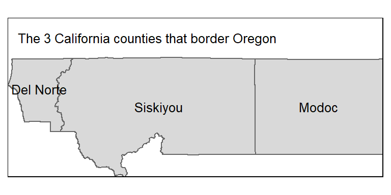

```r
## Start from the California spatial tibble
cali_sf %>%
  ## Filter to just the 3 counties that border Oregon
  filter(COUNTY_NAM == "Del Norte" | COUNTY_NAM == "Siskiyou" | COUNTY_NAM == "Modoc") %>%

## Start our map in tmap using tm_shape()
tm_shape() +

  ## Give it a default color fill
  tm_fill() +

  ## Draw some default borders
  tm_borders() +

  ## Add text to identify the counties by name
  tm_text("COUNTY_NAM",
          size = 0.8) +

  ## Let's give it a title:
  tm_layout(
      "The 3 California counties that border Oregon",
      inner.margins = c(0, 0, 0.25, 0),
      title.size = 0.8)
```

#### Question 4 [1 point]:

Do the same with `ggplot2` including adding the text labels and the title. #RRC

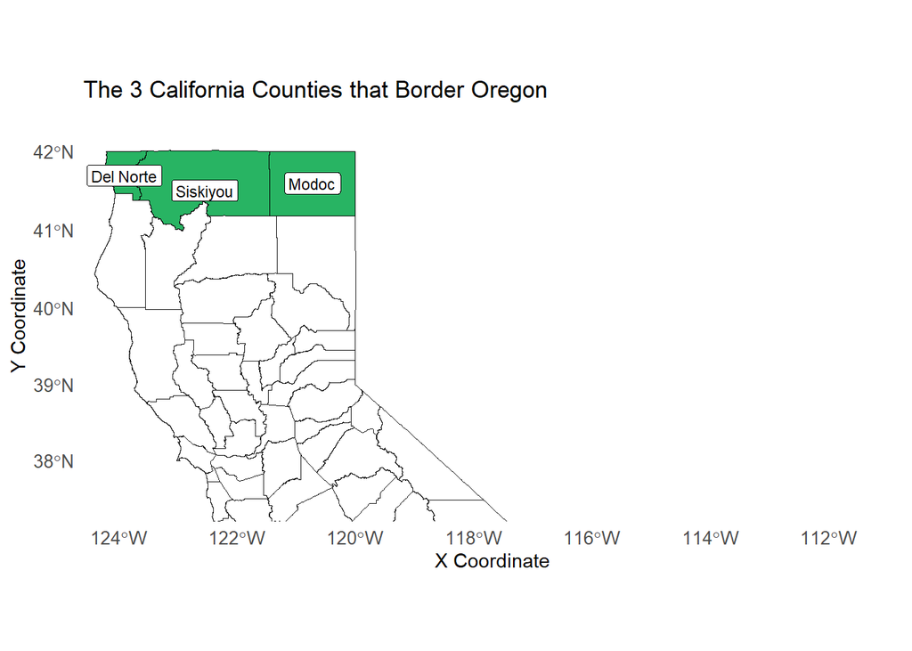

```r
# Filter to just the 3 counties that border Oregon.
counties_bordering_or = cali_sf %>%
  filter(COUNTY_NAM %in% c("Del Norte", "Siskiyou", "Modoc"))

# Plot using ggplot2.
ggplot() +

  # Add county boundaries.
  geom_sf(data = cali_sf, fill = "white", color = "grey10") +

  # Highlight counties that border Oregon.
  geom_sf(data = counties_bordering_or, fill = "#28B463", color = "grey1") +

  # Add county name labels.
  geom_sf_label(data = counties_bordering_or, aes(label = COUNTY_NAM), size = 3) +

  # Customize plot appearance.
  labs(title = "The 3 California Counties that Border Oregon",
       x = "X Coordinate", y = "Y Coordinate") +  # Labels for axes.
  theme_minimal() +  # Minimalist theme.
  theme(panel.grid = element_blank(), # Remove background grid.
        axis.text = element_text(size = 10)) +  # Adjust text size.
  coord_sf(xlim = c(-13800000, -12400000), ylim = c(4500000, 5200000))  # Adjust zoom level.
```

## 2.4 Joining shapefiles with a tibble or dataframe

As mentioned above, the `sf_read()` function from the `sf` package loads our shapefile as a `tibble`, which makes life much easier for us when dealing with shapefiles. It also means we can easily join our shapefiles with other tibbles / dataframes, like the ones we’ve imported of mortality data. Let’s briefly breakdown what our process to do this is going to look like:

**Our Process:**

- Rename the **County** column so it matches the shapefile
- Summarize the data by **Year** so we can visualize the annual trends
- Join the two tibbles by `COUNTY_NAME`
- Make sure to turn the joined tibble **back into a shapefile** using the `st_as_sf()` function, otherwise it will fail. The join will convert it into a structure that is no longer a shapefile, so you have to back-convert it to a shapefile!
- We are going to remove the islands, not because we dislike islands but because they get labeled separately and make our map look cluttered. Further, the few people who reside on the islands of California will still be included in their onshore county, so we are not ignoring anyone. *Feel free to experiment removing that filter to see what I mean!*

#### Question 5 [1 point]:

Annotate the following code chunk with comments to make sure you understand what we are doing here. #RRC

```r
# Extracting mortality data and preparing for spatial analysis. -- I stuck with death and mortality here.
mortality_sf <- totalDeaths %>%

  # Renaming the County column to COUNTY_NAM, to remain with the spatial data.
  rename(COUNTY_NAM = County) %>%

  # Grouping the mortality data in each county by year, and month.
  group_by(COUNTY_NAM, Year, Month) %>%

  # Summarizing the total deaths in each county by year, and month.
  summarise(totalDeaths = sum(totalDeaths, na.rm = TRUE)) %>%

  # Performing a full join with cali_sf based on the renamed column and the existing column COUNTY_NAM.
  full_join(cali_sf, by = "COUNTY_NAM", relationship = "many-to-many") %>%

  # Converting the resulting tibble to an sf object..
  st_as_sf() %>%

  # Filtering out the counties that are islands.
  filter(is.na(ISLAND))
```

#### Question 6 [1 point]:

What does `st_join()` do? Could you have executed the join with `st_join()` instead of `full_join()` here? Why or why not? #RRC > `st_join()` lets you perform spatial joins on sf objects based on spatial relationships like intersects, and overlaps. It looks at geometry when joining. In the code above we just used full join instead of st join because the totalDeaths column we made was not a spatial data column we joined a numerical column with spaitial data not spatial data to spatial data so full join was the right one to do. st join would not of worked due to how it was made

## 2.5 Visualizing annual trends in overall mortality

We are asked to make four maps, one for each year, that shows how annual overall mortality trends might be changing as a result of the COVID-19 pandemic. Notice that we are using the `tmap` package again. Notice also that I am first using a `group_by()` and a `summarize()` to tally the total deaths per county per year. Lastly, let’s apply a `tm_facet()` to `Year` to visualize the total deaths by California counties for each of the four years.

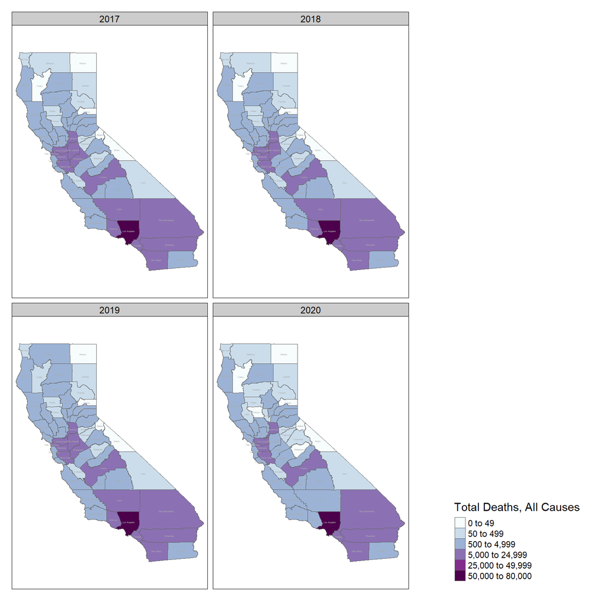

```r
## Start from the mortality spatial tibble
mortality_sf %>%
  ## Group by and then summarize to total the deaths by County and Year
  group_by(COUNTY_NAM, Year) %>%
  summarise(totalDeaths = sum(totalDeaths, na.rm = TRUE)) %>%
## Plot with tmap: tm_shape gets us started
tm_shape() +
  ## Chloropeth: draw the polygons of the counties and fill with color per the total deaths
  tm_polygons(col = "totalDeaths",
              palette=get_brewer_pal(palette="BuPu", n=10, plot=FALSE),
              breaks = c(0, 50, 500, 5000, 25000, 50000, 80000),
              alpha = 1,
              title = "Total Deaths, All Causes") +
  ## Draw some borders
  tm_borders() +
  ## Label the counties with their names
  tm_text("COUNTY_NAM", size=0.25, col = "darkgrey") +
  ## Facet by year
  tm_facets(by = "Year", ncol = 2) +
  ## Make a grid layout
  tm_layout(legend.position = c("right", "bottom"),
            title.position = c('right', 'top'))
```

### Uh oh, can you spot the problem?

Hopefully, you noticed very quickly that the more populous counties in California, *e.g.*, Los Angeles county, have very high mortality rates. Well, duh! If they have more folks… mortality will be higher. So, we need to adjust for population size! But how can we get population data if our dataframes do not already include those data. We could look it up or even download it from the US Census Bureau OR… we could learn how to access data even faster (which also means we can more quickly and iteratively access data) through the Census Bureau’s API.

## 2.6 Accessing the 2020 US Census API

If you have not yet worked with an API, never fear! That’s why we’re doing it here. An **API** (Application Programming Interface) is an intermediary that allows you to access data or other information often from a database (but it doesn’t have to be) in JSON (Java Script Object Notation) or other format. By connecting to the API for the Census Bureau, we will be able to download instantaneously just the data we want, which in our case will be population sizes and some basic demographics about the breakdown of population by sex and by individuals over the age of 65 years.

Because the US Census API uses JSON formatted files, we will be using the `jsonlite` package to convert the JSON files to a dataframe. But first, you need to access the API!

### 2.6.1 Getting your first Census API Key (unless you already have one)

In order to access the Census API, you will need your own Census API key. I could give you mine, but it’s generally not good practice to share API keys unless you trust the person. Why? (1) If someone misuses your API key, you could get banned from accessing the API. (2) Especially for government or non-profit agencies, it can be a good idea to have your own so that they can keep track of how many users they have. Not all API access is free, but for government, non-profit, or institutionally held data, access is free although you may have different hoops to jump through for access depending on how secure they want to keep the data. (e.g., to protect survey respondents).

#### Question 7 [1 point]:

You will sign up for your API census key [here](https://api.census.gov/data/key_signup.html). You should be able to obtain your key very quickly, but if you run into trouble then I will give you the data I have downloaded through **my** API key so that you can still keep going with the project. #RRC Once your have your key, fill it into this code chunk here:

```r
## Set your API key (put it between the quotation marks):
key <- "ea92b7345c7058b38dc5a5c36832a78e52dcc5e0" # Ryan's API key
```

### 2.6.2 Downloading data tables from the 2020 Census API

**NOTE** Make sure to change `include=FALSE` to `TRUE` in the first line (the `{r}` setup line) the chunk or you will get an error upon knitting.

### 2.6.3 Joining the census with the spatial data and updating the maps

#### Question 8 [3 points]:

Your task is to join the census data to the shapefile of overall mortality we’ve already made. We want a tibble that contains all of the data from the census dataframe and all of the data from `mortality_sf`. I called mine `mortality_sf2` but you may call yours anything you’d like. #RRC * **Hint 1**: The easiest way is to use the FIPS data to join.

- **Hint 2**: Don’t worry about calculating % mortality yet.
- **Hint 3**: If you’re having problems, check your data types!

```r
# Perform the left join based on FIPS code (COUNTY in census, COUNTY_FIP in mortality_sf)
mortality_sf2 <- left_join(mortality_sf, census, by = c("COUNTY_FIP" = "COUNTY"))

# View the resulting tibble
head(mortality_sf2)
```

```
## Simple feature collection with 6 features and 21 fields
## Geometry type: MULTIPOLYGON
## Dimension:     XY
## Bounding box:  xmin: -13622600 ymin: 4502573 xmax: -13521880 ymax: 4566129
## Projected CRS: WGS 84 / Pseudo-Mercator
## # A tibble: 6 × 22
## # Groups:   COUNTY_NAM, Year [1]
##   COUNTY_NAM  Year Month totalDeaths COUNTY_ABB COUNTY_NUM COUNTY_COD COUNTY_FIP
##   <chr>      <int> <int>       <int> <chr>           <int> <chr>      <chr>
## 1 Alameda     2017     1        1048 ALA                 1 01         001
## 2 Alameda     2017     2         831 ALA                 1 01         001
## 3 Alameda     2017     3         880 ALA                 1 01         001
## 4 Alameda     2017     4         859 ALA                 1 01         001
## 5 Alameda     2017     5         852 ALA                 1 01         001
## 6 Alameda     2017     6         772 ALA                 1 01         001
## # ℹ 14 more variables: ISLAND <chr>, GlobalID <chr>,
## #   geometry <MULTIPOLYGON [m]>, NAME <chr>, totalN <dbl>, malesN <dbl>,
## #   femalesN <dbl>, over65 <dbl>, `over65%` <dbl>, `males65+` <dbl>,
## #   `males65+%` <dbl>, `females65+` <dbl>, `females65+%` <dbl>, STATE <chr>
```

**Note**: If you’re unable to do this for any reason, you can pick back up here. You will need to download the data from [Google Drive](https://drive.google.com/file/d/15MT127zoySDS7kOfr9uhLwPSIWBCok1W/view?usp=sharing), if needed, as the shapefile is too large for GitHub yet again. I have placed mine on my Desktop, but you can put it anywhere you like and update the directory path. Just make sure not to put it in your GitHub repo!

```r
#load("~/Desktop/mortality_sf2.Rdata")
```

```
## [1] "The five-number summary of annual % total mortality is: "
```

```
## [1] "Min 0"                "Lower Quartile 0.494" "Median 0.648"
## [4] "Upper Quartile 0.778" "Max 1.392"
```

Now let’s plot it:

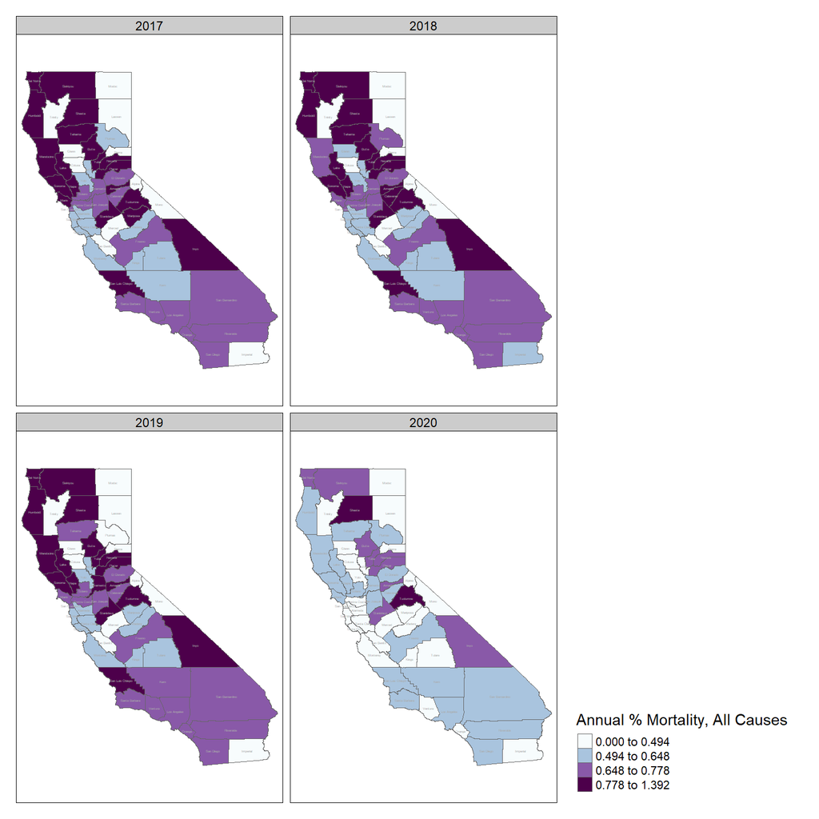

#### Question 9 [2 points]:

What patterns do you observe now, if any? Do you think this is a true pattern? Aren’t we being told that deaths are going **up** due to COVID-19?? #RRC > The pattern that I observe is that in they years 2017, 2018, and 2019, there were very high mortality rates in the north, and northern coastal counties, and high mortaility rates in the southern counties. This is indicated by the dark purple counties and purple counties in the north and south respectively. However in 2020 when COVID-19 started all the mortality rates in pretty much every county drop by at least one tier. I think this is a true pattern due to the fact that everyone had to quarantine so there was less human interactions and less chance for other diseases to spread or crime to happen. These maps show all causes not just deaths by COVID-19 so the statement “that deaths are going **up** due to COVID-19” could be true but relative to all other causes of death in CA it would appear to be lower.

# 3 The data for 2020 isn’t complete…

Ohhhh… that’s right. The pattern observed is simply a by-product of an incomplete record from 2020, isn’t it?! We only have 8 months’ of observations. You realize at this point you were so excited to jump into map-making that you missed something in how you were doing your calculations and/or planning your maps.

```r
## Remove the extra characters from the name of the county
census <- census %>%
  mutate(NAME = gsub(" County, California", "", NAME)) %>%
  rename(County = NAME)

## Join with the total deaths
totalDeaths <- totalDeaths %>%
  full_join(census, by = "County")
```

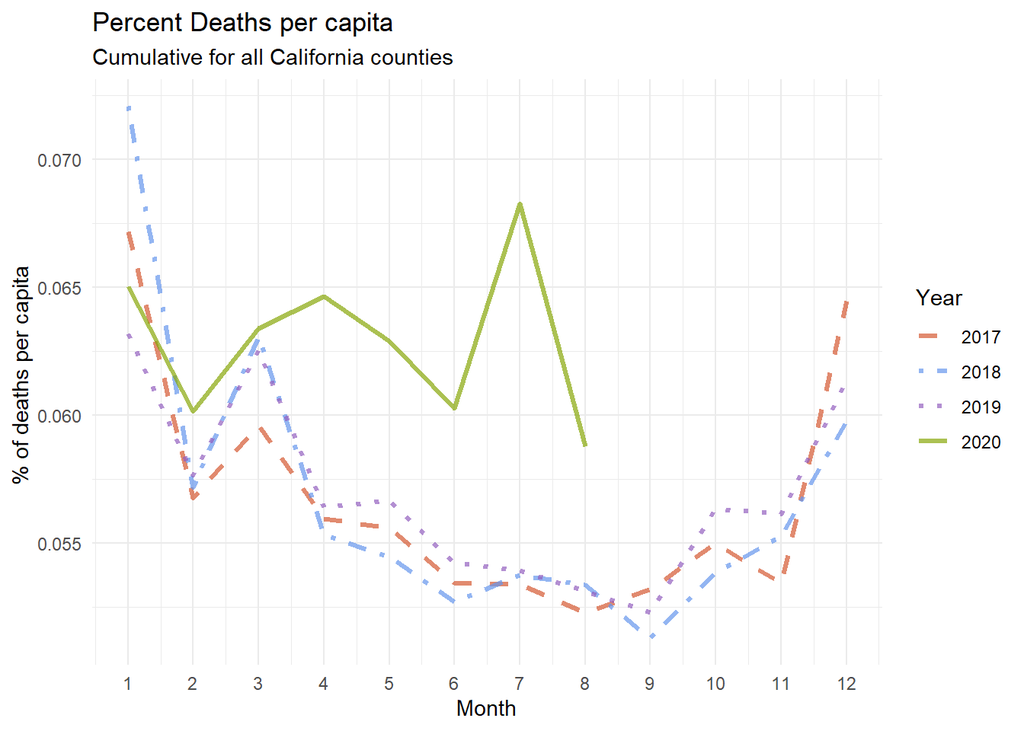

#### Question 10 [1 point]:

Why did this happen and how could we fix it? (**There is more than one correct answer possible.**) Could we have made our maps this way and had them be accurate if we’d had a full 12 months’ of data for each year? #RRC > The maps appeared the way they did because in the years before COVID-19 (2017, 2918, and 2019) they had 4 more months of data when compared to 2020 so even though there are more deaths in 2020 by month, overall there appeared to be more deaths in the previous years due to them having more data. To fix this we could only look at the first 8 months of each year and then re-compare the numbers and maps.

## 3.1 Fixing the map’s accuracy.

Although there are several ways we could tackle this, for the map I am going to choose to take an average of monthly % mortality so that it no longer matters whether we have 8 months’ or 12 months’ of data available for any given year.

```r
## Calculate the monthly percent mortality
mortalityMonthly_sf2 <- mortality_sf2 %>%
  group_by(COUNTY_NAM, Year, Month) %>%
  summarize(percMortality = 100*(sum(totalDeaths, na.rm = TRUE)/mean(totalN))) %>%
  ## Note that I have to divide by the mean of the N from the Census or I'd get an error
  ungroup()

## Find the five number summary
summ <- fivenum(mortalityMonthly_sf2$percMortality)
print("The five-number summary of % mortality is:")
```

```
## [1] "The five-number summary of % mortality is:"
```

```r
summ
```

```
## [1] 0.00000000 0.04780236 0.05833171 0.07265292 0.16220308
```

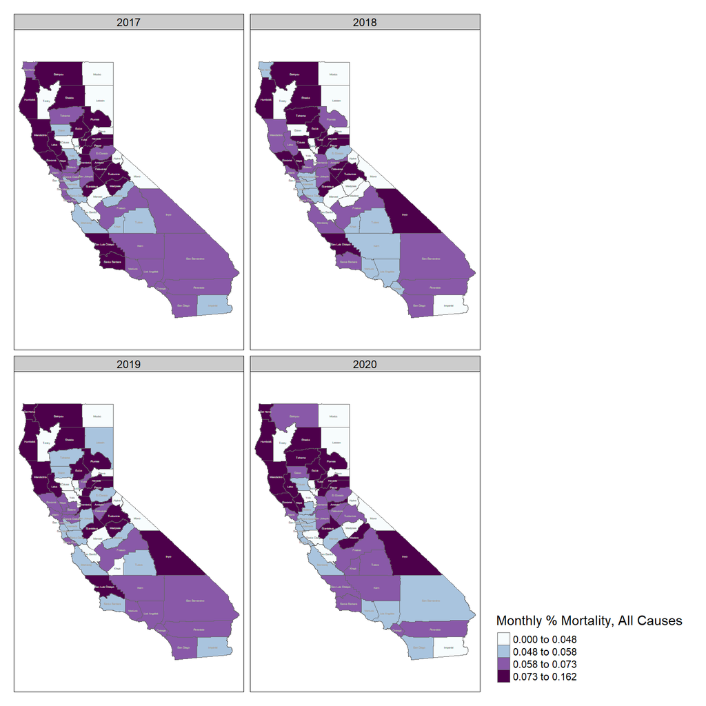

#### Question 11 [3 points]:

Now try executing a different way to more accurately portray the % mortality. (**Hint**: If you need an idea to get you started, ask yourself if you could filter the `mortality_sf2` tibble in some way to restrict what is plotted.) What do you observe, and how do the results compare to the map I chose to make?

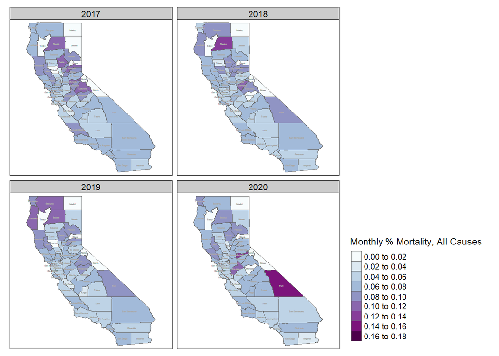

```r
# #Malek
filtered_mortality_sf2 <- mortality_sf2 %>%
  filter(totalN > 1000)

filtered_mortalityMonthly_sf2 <- filtered_mortality_sf2 %>%
  group_by(COUNTY_NAM, Year, Month) %>%
  summarize(percMortality = 100 * (sum(totalDeaths, na.rm = TRUE) / mean(totalN, na.rm = TRUE)), .groups = 'drop')

breaks <- pretty(range(filtered_mortalityMonthly_sf2$percMortality, na.rm = TRUE), n = 10)

tm_shape(filtered_mortalityMonthly_sf2) +
  tm_polygons(
    col = "percMortality",
    palette = get_brewer_pal(palette = "BuPu", n = 10, plot = FALSE),
    breaks = breaks,
    alpha = 1,
    title = "Monthly % Mortality, All Causes"
  ) +
  tm_borders() +
  tm_text("COUNTY_NAM", size = 0.25, col = "darkgrey") +
  tm_facets(by = "Year", ncol = 2) +
  tm_layout(
    legend.position = c("right", "bottom"),
    title.position = c('right', 'top'))
```

# 4 Project future mortality

Your stakeholders have asked if you can quickly give them some idea of what to expect mortality will look like for the remaining months of 2020. Now, although this is not going to be the most robust method for time series projection available (**a caveat!**), you immediately tell me, “Oh, I could do a regression.” So, you do.

## 4.1 Regression predictions of mortality in 2020

```r
mod <- lm(percMortality ~ COUNTY_NAM + Year + Month, data = mortalityMonthly_sf2)
# plot(mod)

## Make the new data:
## Get the names of the counties; repeat four times for the 4 months
COUNTY_NAM <- rep(unique(mortalityMonthly_sf2$COUNTY_NAM), 4)
## Make a set of months for each of the 58 counties for Sept, Oct, Nov, Dec
Month <- c(rep(9, 58),
            rep(10, 58),
            rep(11, 58),
            rep(12, 58))
Year <- rep(2020, length(Month))
newdata <- cbind.data.frame(COUNTY_NAM, Year, Month)

## Attach it to the dataframe and then call it the same name as the original Y
newdata$propDeaths <- predict(mod, newdata = newdata)
newdata$isPredicted <- "1"
```

Let’s finish out the year of 2020 with predictions (shown in bubble points):

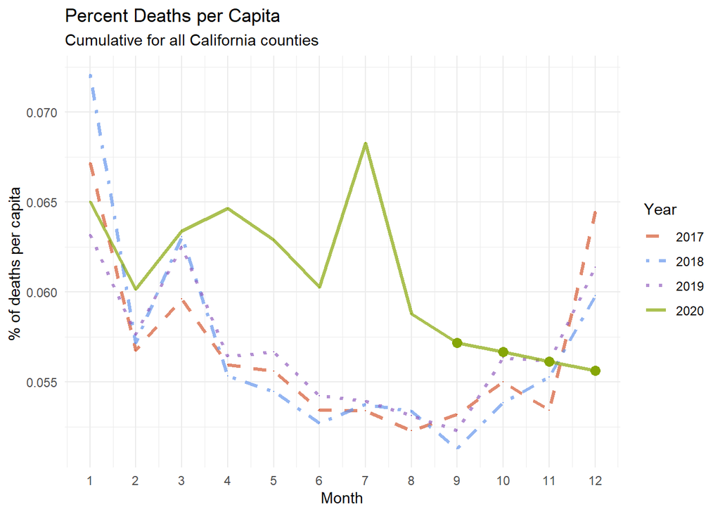

#### Question 12 [1 point]:

Do you think this regression prediction is robust? Why or why not? (**Hint**: Check your assumptions with `plot(mod)`!!)

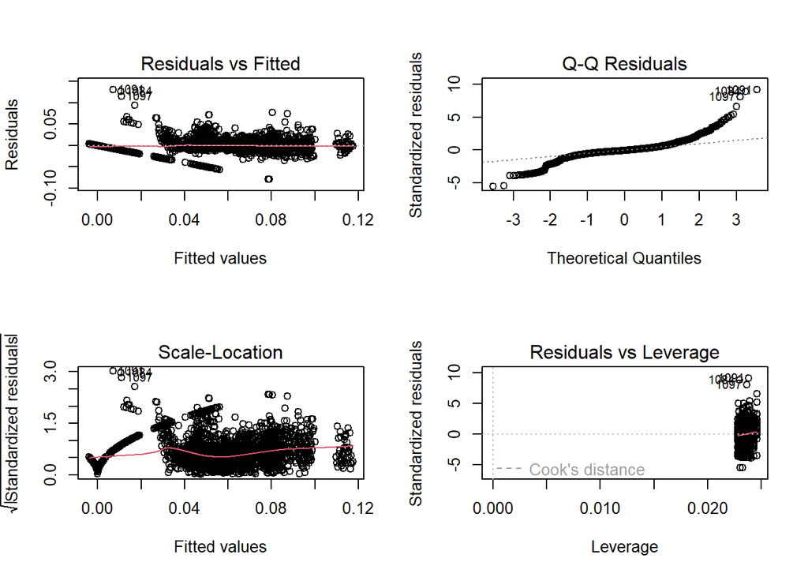

```r
# #Malek
mod <- lm(percMortality ~ COUNTY_NAM + Year + Month, data = mortalityMonthly_sf2)

par(mfrow = c(2, 2))
plot(mod)
```

```r
par(mfrow = c(1, 1))
```

> #Malek - In order to make sure the prediction is indeed robust it’s important to evaluate a few things including linearity, normality, and independence. For the most part, this is not really a model I would like to put my name beside. It appears that there is room to improve and I definitely think it can be done.

## 4.2 Showing the predictions on a map

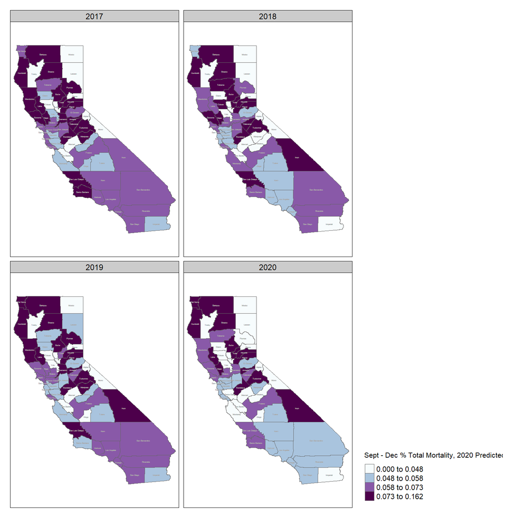

# 5 Improving Predictions

By now, you have probably realized that the regression we did is neither adequate nor to be trusted. Your task is to **improve the prediction**. Lay out a brief **analysis plan**, defend your choice of machine learning algorithm, and attempt to update **at least the map** if not also the line graph. Be sure to include an RMSE or some other metric to show how your prediction is performing.

*Wait, how?* Ah, the pandemic is over in reality! You can find the actual number of deaths, per county, [here](https://data.chhs.ca.gov/dataset/death-profiles-by-county/resource/579cc04a-52d6-4c4c-b2df-ad901c9049b7).

**Hint**: You can read this file in as a dataframe using JSON API as follows!

```r
deaths2020 <- fromJSON("https://data.chhs.ca.gov/datastore/odata3.0/579cc04a-52d6-4c4c-b2df-ad901c9049b7?$top=5&$format=json")
```

**Remember** to filter for the proper condition, Year, and Months to get the data you need for your testing set.

#### Question 13 [15 points]:

> #Malek - The first model was too simple and did not meet the necessary criteria I was looking for. The following random forest is obviously more complex while also diving much deeper than a linear regression can.

```r
##Malek

deaths2020 <- fromJSON("https://data.chhs.ca.gov/datastore/odata3.0/579cc04a-52d6-4c4c-b2df-ad901c9049b7?$format=json")
deaths2020 <- deaths2020$value

deaths2020 <- deaths2020 %>%
  mutate(Month = as.numeric(substr(month, 6, 7)),
         Year = as.numeric(substr(month, 1, 4)),
         totalDeaths = as.numeric(total_deaths)) %>%
  select(County, Year, Month, totalDeaths) %>%
  rename(COUNTY_NAM = County)
```

[output not shown]

```r
merged_data <- mortalityMonthly_sf2 %>%
  left_join(deaths2020, by = c("COUNTY_NAM", "Year", "Month"))
```

[output not shown]

```r
set.seed(15)
rf_model <- randomForest(percMortality ~ COUNTY_NAM + Year + Month + totalDeaths, data = merged_data, na.action = na.omit)
```

[output not shown]

```r
newdata$propDeaths <- predict(rf_model, newdata = newdata)
```

[output not shown]

```r
predictions <- predict(rf_model, newdata = merged_data)
```

[output not shown]

```r
rmse <- sqrt(mean((merged_data$percMortality - predictions)^2, na.rm = TRUE))
```

[output not shown]

```r
print(paste("RMSE of the Random Forest model:", round(rmse, 2)))
```

[output not shown]

```r
newdata$isPredicted <- "1"

temp <- deaths2020 %>%
  group_by(Year, Month, COUNTY_NAM) %>%
  summarise(propDeaths = sum(totalDeaths, na.rm = TRUE) / sum(totalN, na.rm = TRUE) * 100) %>%
  mutate(isPredicted = "0")
```

[output not shown]

```r
temp2 <- newdata %>%
  group_by(Year, Month, COUNTY_NAM, isPredicted) %>%
  summarize(propDeaths = mean(propDeaths))
```

[figure not shown]

```r
temp <- rbind(temp, temp2)

regressionPredicted <- temp %>%
  full_join(cali_sf, by = "COUNTY_NAM", relationship = "many-to-many") %>%
  st_as_sf() %>%
  filter(is.na(ISLAND)) %>%
  filter(Month >= 9)

tm_shape(regressionPredicted) +
  tm_polygons(
    col = "propDeaths",
    palette = get_brewer_pal(palette = "BuPu", n = 10, plot = FALSE),
    alpha = 1,
    title = "Sept - Dec % Total Mortality, 2020 Predicted"
  ) +
  tm_borders() +
  tm_text("COUNTY_NAM", size = 0.25, col = "darkgrey") +
  tm_facets(by = "Year", ncol = 2) +
  tm_layout(
    legend.position = c("right", "bottom"),
    title.position = c('right', 'top')
  )
```

```r
temp <- deaths2020 %>%
  group_by(Year, Month) %>%
  summarise(propDeaths = sum(totalDeaths, na.rm = TRUE) / sum(totalN, na.rm = TRUE) * 100) %>%
  mutate(isPredicted = "0")
```

[output not shown]

```r
temp2 <- newdata %>%
  group_by(Year, Month, isPredicted) %>%
  summarize(propDeaths = mean(propDeaths))
```

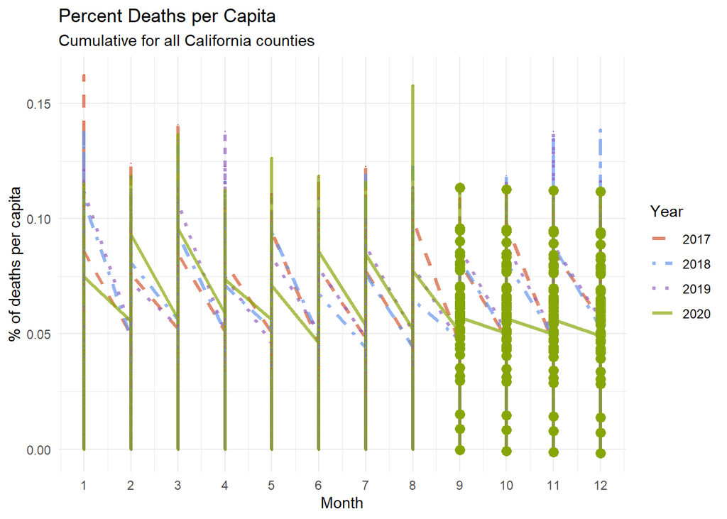

```r
temp <- rbind(temp, temp2)

temp %>%
  ggplot(aes(x = Month, y = propDeaths, color = as.factor(Year), linetype = as.factor(Year))) +
  geom_line(alpha = 0.7, size = 1.1) +
  geom_point(aes(size = isPredicted), show.legend = FALSE) +
  scale_x_continuous(n.breaks = 10) +
  scale_color_manual(values = c("#d45731", "cornflowerblue", "#925ebf", "#86a607")) +
  scale_linetype_manual(values = c("dashed", "dotdash", "dotted", "solid")) +
  scale_size_manual(values = c(0, 3)) +
  labs(
    title = "Percent Deaths per Capita",
    y = "% of deaths per capita",
    subtitle = "Cumulative for all California counties",
    color = "Year",
    linetype = "Year"
  ) +
  theme_minimal()
```

If this open-ended analysis feels overwhelming, just ask for more hints to get you started!

# 6 Testing Hypotheses

California was one of the strictest states when it came to shutdown measures during the COVID-19 pandemic, with both statewide enforcement and a duration longer than some other states in the country. California declared a state of emergency on **March 4, 2020** with a a mandatory statewide stay-at-home order issued on **March 19, 2020**. This statewide order didn’t end until **January 25, 2021**, but it still wouldn’t be until April 6, 2021 when the state announced plans to fully reopen the economy by **June 15, 2021**.

Your stakeholder is actually not as interested in deaths from COVID-19, but actually more interested in how the mandatory stay-at-home order seems to affecting mortality due to certain conditions. For example, are people less likely to die from accident or injury since they’re under stay-at-home orders?

## 6.1 Death from Accident & Injury

Because of the mandatory COVID-19 shutdown in California, which has led to generally reduced movement throughout California, your stakeholder would like to know if the number of accidental deaths declined enough **during COVID-19 shutdown** to generate a signal.

**HYPOTHESIS**: I hypothesize that because of intense, mandatory stay-at-home measures, deaths attributed to accidents and injuries (`INJ`) declined during the COVID-19 shutdown during the months of 2020 in California.

So, let’s test it! We will start, as with all good analysis plans, with some more **Exploratory Data Analysis**.

### 6.1.1 Sex-specific Effects on `INJ` Mortality

#### Total Deaths by Sex

The leading causes of death is located in the `sexDeaths` table because that was how the data were provided to us. They are separated by sex, thus we can check to see if there are sex differences we should worry about before proceeding. We do need to join some of our tables and calculate some additional metrics as well, including:

- Proportion of deaths from accident or injury out of all deaths (no longer adjusting for population size)
- Ratio of adult females to males in the population
- Ratio of females to males in the population among those over 65 years of age
- Ratio of all adults over the age of 65 (retirement age) to those under retirement age

We have opted to adjust per total deaths, rather than population size, so that we can now better examine the fraction of deaths due to particular causes regardless of the underlying size of the population. However, we do need to account for the ratio of females to males in the population, as well as it might be useful now or in future analyses to have access to the ratio of females to males just among those over the age of 65 as well as the ratio of retirees (65+ years old) to non-retirees in the population.

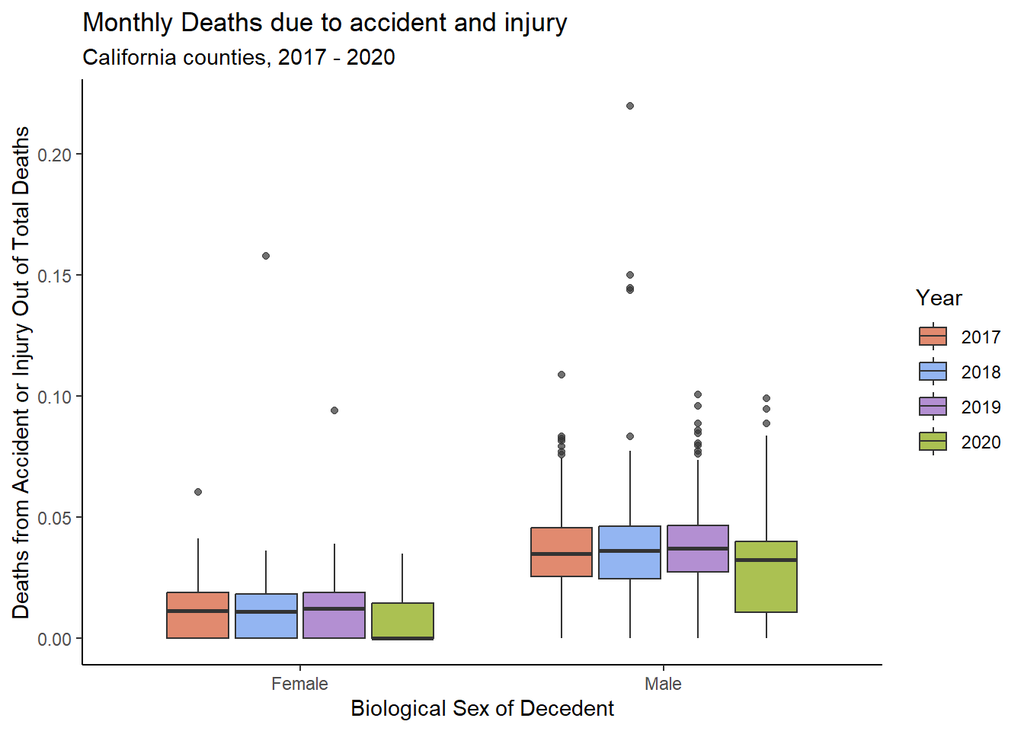

```r
## Join the sex deaths table with the census data; then filter for INJ
injDeaths <- sexDeaths %>%
  full_join(census, by = "County") %>%
  filter(leadingCauseDeath == "INJ") %>%
  ## Now full join with the first 4 columns of the totalDeaths table to get total deaths also
  full_join(totalDeaths[ , 1:4], by = c("County", "Year", "Month")) %>%
  ## rename the sexDeaths column to something more appropriate
  rename(injuryDeaths = sexDeaths) %>%
  ## Calculate the proportion of all deaths that are from injury RELATIVE TO ALL DEATHS (not population)
  mutate(deathsInjuriesProportion = injuryDeaths/totalDeaths,
         femaleMaleRatio = femalesN/malesN,   ## The ratio of females to males in the population
         femaleMaleRatio65 = `females65+`/`males65+`,  ## The ratio of 65+ females to males in the population
         retireeRatio = over65/totalN,  ## Ratio of retirees to non-retirees
         Date = as.Date(paste(Year, Month, "1", sep = "-"), format = "%Y-%m-%d"),   ## Convert the date to a date format for plotting
         deathsInjuriesProportion = ifelse(deathsInjuriesProportion == "NaN", 0, deathsInjuriesProportion))  ## Illegal div by 0 turned to NaN; turn back to 0
```

#### Question 14 [1 point]:

Is it fair to model the values without accounting for an effect of sex, do you think? Why or why not?

> #Malek - I would probably say that it doesn’t make the most sense to consider this a fair model without accounting for sex. I feel as though sex could provide some valuable insight which is due to some of the inherent biological differences between sex. Additionally, there may be different behaviors for the different sexes which could also definitely have an impact.

#### Proportion of Deaths by Sex

What if we calculate the proportion of deaths, for each gender, instead? Wouldn’t that give us a more accurate portrait of any sex-level differences that might exist?

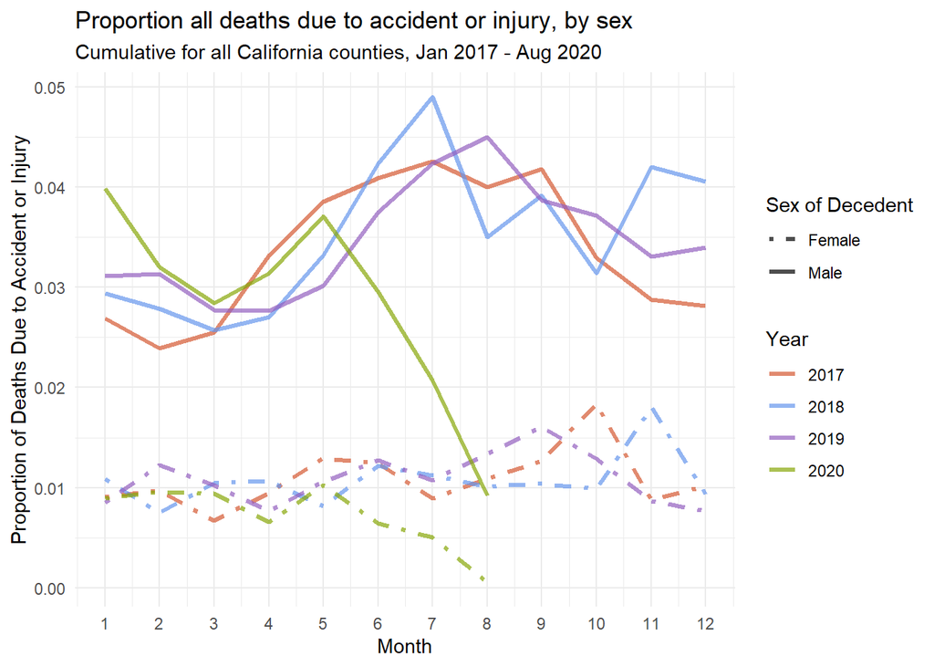

```r
injDeaths %>%
  group_by(Month, biologicalSex, Year) %>%
  summarise(deathsInjuriesProportion = mean(deathsInjuriesProportion, na.rm = TRUE)) %>%
ggplot(aes(x = Month,
           y = deathsInjuriesProportion,
           color = as.factor(Year),
           linetype = as.factor(biologicalSex))) +
  geom_line(alpha = 0.7,
            size = 1.1) +
  scale_x_continuous(n.breaks = 10) +
  scale_color_manual(values = c("#d45731", "cornflowerblue", "#925ebf", "#86a607")) +
  scale_linetype_manual(values=c("dotdash", "solid")) +
  labs(title = "Proportion all deaths due to accident or injury, by sex",
       y = "Proportion of Deaths Due to Accident or Injury",
       subtitle = "Cumulative for all California counties, Jan 2017 - Aug 2020",
       color = "Year",
       linetype = "Sex of Decedent") +
  theme_minimal()
```

#### Question 15 [1 point]:

What do you notice about the trend? Is there anything compelling here potentially? Can you find any possible explanation for what happened in May (month 5) of 2020?

> #Malek - So this trend where the female population on average has a significantly lower proportion of deaths due to accident or injury is quite compelling and shows exactly why it is important to map these out seperated by sex. Another trend that I notice is that both male and female tend to increase/decrease at the same time which could be indicating environmental or societal factors. The next thing I would like to point out is how there is a very big drop off in May 2020 for males. My best assumption for this would be due to covid. I’m assuming that the male population had more jobs that could cause death and injury but during covid these jobs slowed down and people were just outside getting injured less in general and thus, less male workers were exhibiting death due to injury or accident which caused a steep drop off in the graph.

### 6.1.2 Mapping injury-related deaths by stay-at-home orders & sex

So, hopefully you noticed what I’ve noticed about the relationship between the stay-at-home orders and the proportion of overall deaths due to accident or injury, as well as the effect of the shutdown in terms of both decedent biological sexes. We know from our earlier graph that females have a lower proportion of overall death due to accident or injury; next, it would be nice to see what the relationship is spatiotemporally (before and after shutdown) on average accident / injury mortality overall, as well as for each of the sexes separately. This will allow us to see if there is a geographic pattern, as one might expect in denser areas with more roadways, with the effect or not.

Let’s add a label to the dataset to identify whether a month was under stay-at-home orders or not, and call the new feature `stayAtHome`. Notice that I could have coded it as a dummy variable (0 or 1) where 1 is the stay-at-home order condition, but instead I chose to encode it as a category. I can also change the encoding later, if needed. Note also that although I chose to use `Date` as the condition for my `ifelse()`, you could just as easily have chosen a joint conditional using both`Month` and `Year` columns!

```r
## Encode stayAtHome as any date after March 19, 2020
injDeaths <- injDeaths %>%
  mutate(stayAtHome = ifelse(Date >= "2020-03-19", "Stay-at-Home", "None"))
```

Next, let’s calculate a summarized dataframe that groups by `stayAtHome`, `Year`, and `County`, then summarizes an average `deathsInjuriesProportion` for use with the maps. Notice that rather than storing the summarized dataframe, I simply piped it through to join it with the geometry from the shapefile for map-making this time. I was feeling a bit lazy.

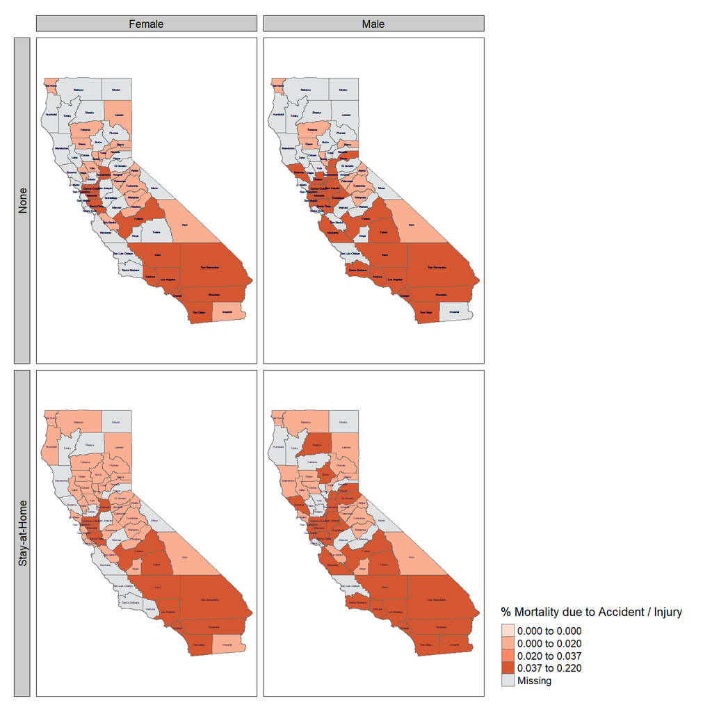

#### Question 16 [1 point]:

Do you think there is any evidence that the proportion of deaths due to accident & injury changed as a result of the stay-at-home orders? What would provide stronger evidence of a change in proportion of deaths due to accident and injury as a result of the shutdown? Is there any evidence of interaction with the sex of the decedent?

> #Malek - I would say that there is moderate evidence for proportion of deaths due to accident and injury being changed as a result of the stay-at-home order. However, if I want to have stronger evidence some of the things I could do would be to do some statistical analysis like a t test or time series analysis.

Now, what if we wanted to attempt to control for any underlying population-level differences in the sex ratio of each county? Although we expect, *a priori*, for all counties to have a female to male ratio of 1:1, we know that in reality that isn’t always the case.

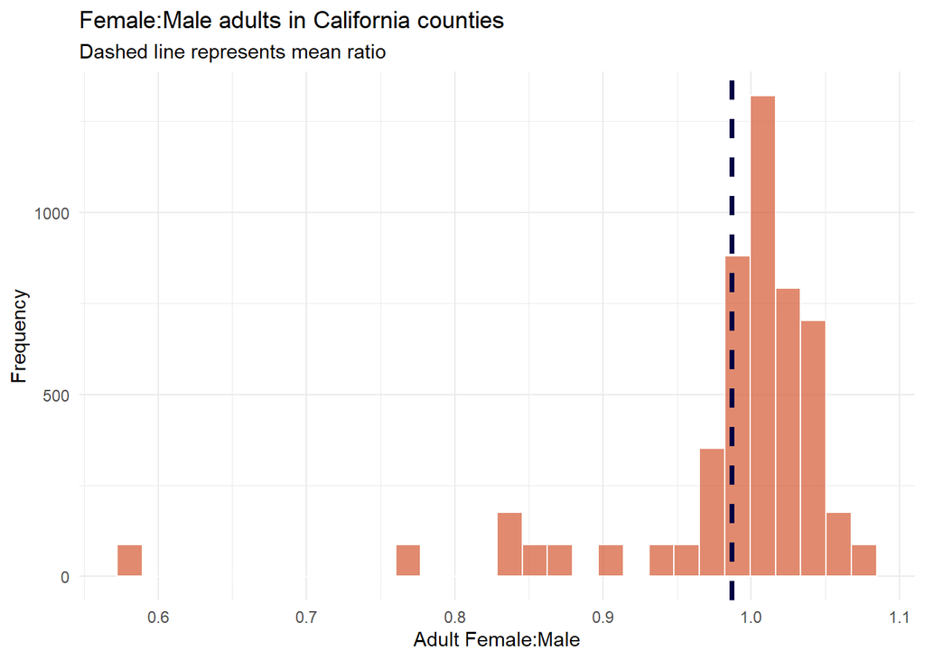

#### Question 17 [1 point]:

Calculate the correlation of `femaleMaleRatio` and the `deathsInjuriesProportion`, making sure to be careful to drop or exclude any NAs before making your calculation.

```r
# #Malek

correlation_data <- injDeaths %>%
  select(femaleMaleRatio, deathsInjuriesProportion) %>%
  filter(!is.na(femaleMaleRatio) & !is.na(deathsInjuriesProportion))

correlation <- cor(correlation_data$femaleMaleRatio, correlation_data$deathsInjuriesProportion)

print(paste("Correlation between femaleMaleRatio and deathsInjuriesProportion:", round(correlation, 4)))
```

```
## [1] "Correlation between femaleMaleRatio and deathsInjuriesProportion: 0.2798"
```

Do you think that this correlation coefficient indicates that we need to make a correction on our maps, or is it likely sufficient just to make the correction in our models? In other words, large correlation coefficients (in the absolute value sense) would indicate a need to correct the maps; smaller coefficients would indicate that it’s probably not a big deal for our visualizations provided to stakeholders.

> #Malek - I would say that this is probably sufficient enough just to make a correction in the models. The question I would ask though is… what is a correlation coefficient relative to to consider it “high”. I do think though that with some tweaking to the models this would be good enough for shareholders

#### Question 18 [1 point]:

Now, take a look at the scatter plot below with a best-fit line. Does the plot agree with the correlation coefficient (i.e., direction of slope) you obtained? Why or why not?

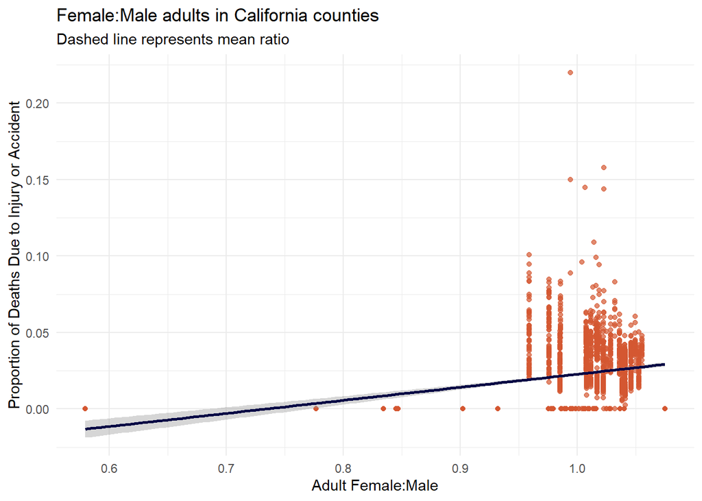

### 6.1.3 Predictive Modeling

With the previous model, I did a subpar linear regression in the hopes that you would improve upon my predictive model. This time, since I am going to have you focus on the **exploration** side of things, I am going to attempt to make a slightly better model – but please be aware that this is NOT as robust as I would like it to be to return to stakeholders. This is more for demonstration purposes so that we can get to our true goal: mapping predictions!

I know from the earlier model diagnostic plots that the linear regression assumptions were not upheld. We have several options we could explore here to make a better model, including performing a Box-Cox transformation, considering a LASSO regression (especially since there could be high collinearity among some counties, especially those that are more urban vs. rural), or even switching to a regression algorithm that is agnostic to the underlying assumptions of Ordinary Least Squares, like a Random Forest. Here, the latter is exactly what we will implement - and we will add another ensemble method, Gradient Boosting Machine (GBM) for comparison.

Before we move forward, let’s also clarify our question a bit.

#### Research Question:

What effect has `County`, `Year`, `Month`, `stayAtHome`, `biologicalSex`, `femaleMaleRatio`, `totalN`, and `retireeRatio` had on the proportion of all deaths that have occurred due to accident or injury?

In other words, does the proportion of accident / injury-based deaths differ by the county where the decedent lived, the month in which the death occurred, whether it is during the COVID-19 stay-at-home order or not, the biological sex of the decedent, the sex ratio of adult females to males in the county, the population size of the county, and the ratio of older adults over 65 years relative to non-retirees?

Wait, why am I throwing `retireeRatio` in there? Ahh, we can think of reasons why accidental deaths might change over the duration of one’s life. Perhaps the relative proportion is unchanged and only the cause of the accidental death might change (i.e., more stunt-based deaths when younger, more falls when older) OR the actual proportion might decline with age because people are generally less active and move / drive around less.

#### 6.1.3.1 Data cleaning

There really isn’t much we need to do here, but I will go ahead and strip the dataset down to just the columns we are going to focus on in the analysis as well as drop any missing values. I am not going to do any imputation of missing values this time because there are some counties for which we just have had **no** reporting. We don’t want to impute for a county that has no data at all.

```r
injDeaths_cleaned <- injDeaths %>%
  dplyr::select(County, Year, Month, stayAtHome, biologicalSex, femaleMaleRatio, totalN, retireeRatio, deathsInjuriesProportion) %>%
  drop_na()
```

### 6.1.3.2 Data partitioning

Before we do any encoding or transformations, let’s do our **test-train split** as we’ve already discussed.

Remember that little function we annotated from last project, the one called `calcSplitRatio`? We are going to load that in and use that function again to help use find our optimum split ratio! I have put it into a `R` script, `calcSplitRatio.R`. Then, we need to pass it our dataframe, `injDeaths` as well as the number of parameters we expect to test. Here the number of parameters is the 58 counties in the dataset as well as the 6 other features (parameters here) we plan to use (`Month`, `stayAtHome`, `biologicalSex`, `femaleMaleRatio`, `totalN`, and `retireeRatio`).

```r
source("../../../../III. Public Health & Epidemiology/Project/calcSplitRatio.R")
train_prop <- calcSplitRatio(df = injDeaths_cleaned, p = (length(unique(injDeaths_cleaned$County)) + 7))  ## 58 counties + 5 more parameters
```

```
## [1] "The ideal split ratio is 0.88:0.12 training:testing"
```

Not too unsurprisingly since this is a smaller dataset, it is recommending a larger training set than we’ve seen before.

```r
ind <- createDataPartition(injDeaths_cleaned$deathsInjuriesProportion,
                          p = train_prop,
                          list = FALSE)

train <- injDeaths_cleaned[ind, ]
test <- injDeaths_cleaned[-c(ind), ]
```

### 6.1.3.3 Make one-hot encoded variables

Next, we need to do our encoding. We are going to do one-hot encoding for all of categorical variables of `County`, `stayAtHome`, and `biologicalSex`. We will manually make for the one-hot encodings for `stayAtHome` and for `biologicalSex` since there are only two conditions in each of those columns; the `dummyVars()` function will try to turn them into two columns, which is both unnecessary AND increases our dimensionality! But we will leverage `dummyVars()` from the `caret` package for the `County` variable to make our life so much easier.

**Note**: I have encoded males as `1` because it is the condition in which we expect a higher proportion of injury-related deaths. Thus, females have been made the reference condition. Additionally, I encoded the `stayAtHome` condition of `None` as 0, making it the reference condition.

```r
encodeTrain <- function() {
## Make one-hot encoded variables manually
train <- train %>%
  dplyr::mutate(stayAtHome = ifelse(stayAtHome == "None", 0, 1),
         biologicalSex = ifelse(biologicalSex == "Male", 1, 0))

## Now make the one-hot encoded County
county <- dummyVars(" ~ County", data = train)
trainReady <- predict(county, newdata = train) %>%   ## Do the encoding
  data.frame() %>%  ## Make a dataframe
  cbind(train) %>%  ## Add back to the train set
  select(-County)   ## Drop the original county

return(trainReady)
}
trainReady <- encodeTrain()

encodeTest <- function() {

## Make one-hot encoded variables manually
test <- test %>%
  mutate(stayAtHome = ifelse(stayAtHome == "None", 0, 1),
         biologicalSex = ifelse(biologicalSex == "Male", 1, 0))

county <- dummyVars(" ~ County", data = test)
testReady <- predict(county, newdata = test) %>%   ## Do the encoding
  data.frame() %>%  ## Make a dataframe
  cbind(test) %>%  ## Add back to the test set
  select(-County)   ## Drop the original county

return(testReady)
}

testReady <- encodeTest()
```

Now, there’s one little problem… that’s a **BIG** problem. Not all of the counties have columns in the `testReady` dataset. Why not? Well, if the **category was missing from the `County` column of the test data set, then the column would not be made by `dummyVar()`!** So, we will need to make a blank column full of zeros for any columns missing from `testReady`. There is a handy function, `setdiff()`, that will allow us to compare two vectors (the names of the columns of the dataframe) and return what is present in the first vector but missing in the second vector.

```r
fixMissingColumns <- function() {
  ## Store the missing columns into a vector
  columns_missing <- setdiff(names(trainReady), names(testReady))
  columns_missing

  ## Make the new columns and populate them with zeros
  testReady[, columns_missing] <- rep(0, nrow(testReady))
  print(paste0("Column comparison: Are they the same now in test and train now? ",
               ncol(testReady) == ncol(trainReady)))

  return(testReady)
}

## Encode train again
trainReady <- encodeTest()

testReady <- fixMissingColumns()
```

```
## [1] "Column comparison: Are they the same now in test and train now? TRUE"
```

We can see that the `testReady` dataset now has the same number of columns as the `trainReady` dataset. Yay! Big little problem solved.

### 6.1.3.4 Center & Scale

This time, we will take advantage of the `preProcess()` function in `caret` as an alternative method. Last time, we used `scale()`. Notice that what `preProcess()` does is centers and scales *relative to the training data* and applies the same centering & scaling factors to the test set.

```r
centerScale <- preProcess(trainReady, method = c("center", "scale"))

trainReady <- predict(centerScale, trainReady)
testReady <- predict(centerScale, testReady)
```

### 6.1.3.5 Random forest with 10-fold cross validation & random hyperparameter search

```r
## Set the control for 10-fold CV
ctrl <- trainControl(method = "cv",
                     number = 10,
                     verbose = FALSE)

## Run a RF with a random search grid
RF <- train(deathsInjuriesProportion ~ .,
               data = trainReady,
               method = "ranger",
               trControl = ctrl,
               search = "random",
               importance = 'impurity')

## Make the predictions against the test dataset
predRF <- predict(RF,
                newdata = testReady)

## Look at the R-squared, RMSE, and MAE
round(postResample(predRF, test$deathsInjuriesProportion), 4)
```

```
##     RMSE Rsquared      MAE
##   0.9242   0.9565   0.8141
```

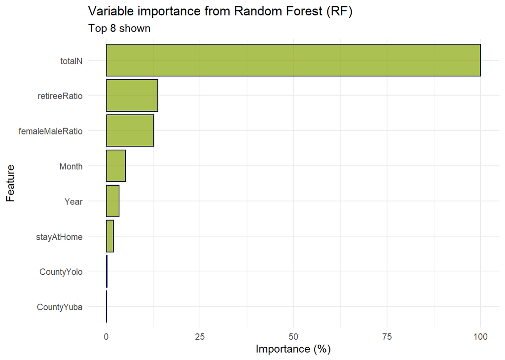

### 6.1.3.6 Gradient boost machines (GBM) regression with 10-fold cross validation & a random hyperparameter search

We have not used a gradient boosting machine yet, so I want to take a moment to orient you to it if you are not familiar with it. Just as with Random Forest, GBMs can be classification or regression models. Gradient boosting is an ensemble method like RF, but whereas RF relies on constructing the forest by improvement of the average error of the models in the ensemble, GBMs are based on a different strategy. In boosting methods, new models are added to the ensemble sequentially instead. At each iteration, a new weak learner model is trained based on the error of the ensemble learned thus far. Gradient boosting methods thus either really outperform other methods OR are severely overfitted, depending on the sequential addition of models to the ensemble. This is because the addition of each new weak learner model will either provide a more accurate estimate of the target or it will be overtrained to the training dataset, thus leading to overfitting.

Each of the weak learners added will have maximum correlation with the negative gradient of the **loss function**, which is set for the entire ensemble. Loss functions can be applied arbitrarily, but it is best to align the loss function with the squared-error loss when possible. One even has the option to assign your own task-specific loss, if needed. You would just need to know what error you are attempting to optimize! Further, GBMs are extremely customizable and one can perform loss function trial and error as well.

The **weak learners** can also be chosen in addition to the loss function, meaning that you can design your GBM to use linear regression, Ridge regression, decision trees, or even your own weak learner!

#### Question 19 [2 points]:

Look for a reliable resource that explains how the GBM algorithm works and do your best to attempt to explain what is happening at each iteration. Make sure to give a link or citation.

> #Malek - So my understanding of what is happening is you start with an initial model, find the residuals, then build a model for the residuals, and update the model based on the residuals model. In each iteration this is done until the model gets better and better. The link that helped me understand GBM more in depth can be found here: https://www.frontiersin.org/journals/neurorobotics/articles/10.3389/fnbot.2013.00021/full

#### Question 20 [2 points]:

What hyperparameters can one tune in a GBM? **Hint**: Make sure to explain at least 4!

> #Malek - This type of question is very fresh in my mind as I am currently taking the artificial intelligence and machine learning course. 4 hyperparameters that can be tuned in a GBM include the number of trees to make sure we are getting the best tuning possible and not overfitting, shrinkage which defines how much each tree has an impact on the final model, tree depth to control the depth of each tree with deeper trees being more complex but more at risk for overfitting, and lastly minimum number of observations which determines minimal number of leaves in trees.

Okay, let’s execute it!

```r
gbmGrid <-  expand.grid(interaction.depth = c(1, 5, 9, 15),
                        n.trees = (1:30)*50,
                        shrinkage = c(0.05, 0.1, 0.15),
                        n.minobsinnode = c(20, 30, 50))

## Run a GBM with a pre-defined search grid
GBM <- train(deathsInjuriesProportion ~ .,
               data = trainReady,
               distribution = "gaussian",
               method = "gbm",
               trControl = ctrl,
               verbose = FALSE)

## Make the predictions against the test dataset
predGBM <- predict(GBM,
                newdata = testReady)

## Look at the R-squared, RMSE, and MAE
round(postResample(predGBM, test$deathsInjuriesProportion), 4)
```

```
##     RMSE Rsquared      MAE
##   0.9208   0.9189   0.8135
```

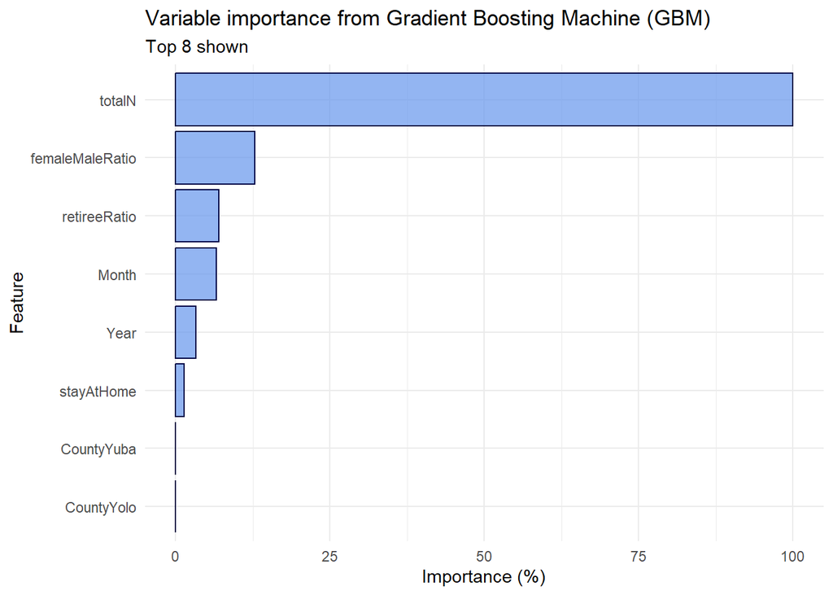

#### Question 21 [1 point]:

Which model is superior and why? Do you trust these results?

> Your answer here. GBM model looks superior

#### Question 22 [1 point]:

Do you trust the variable importance results? Is there any difference in the variable importance between the two models?

> Your answer here.Yes. The varieble results looks trustable.

#### Question 23 [1 point]:

Do you think there is any effect of geography? Why or why not? Would it be worth mapping? (**Hint**: Does the highest-importance variable suggest that there IS or IS NOT an effect of geography?)

> Your answer here.mapping the geographic effect is valuable for understanding relationships and making informed decisions.

#### Question 24 [1 point]:

If we were to proceed with mapping, what recommendations or changes should we implement beforehand? (Try to think about this relative to mapping, predicting, and then mapping the predictions of all mortalities).

> Your answer here.GBM predicts mortality rates for all counties. Choropleth maps are created, visualizing predicted mortality rates across the entire region. Interpretation: We interpret the model coefficients and feature importances in the context of geography. Regions with high or low predicted mortality rates are identified, helping inform public health policies and resource allocation.

#### Question 25 [1 point]:

Do we have any indication, thus far, that the pandemic is reducing the number of injury-related mortalities? Why or why not? What might we need to be able to see a stronger variable importance? (**Hint**: “More time” or “more deaths” are viable options, but there’s another more practical example as well.)

> Your answer here.o see a stronger variable importance, we might need: More Data: Collecting additional data over a longer time frame could reveal more nuanced patterns. Contextual Factors: Consider environmental context (e.g., urban vs. rural) and specific age or sex groups. Behavioral Changes: Analyze changes in behavior due to pandemic-related restrictions (e.g., reduced mobility, altered work patterns).